# R Notebook

# AUTHOR: JORDI TARROCH MEJÓN

El archivo H1 consta de 40.060 observaciones efectuadas sobre 31 variables en un hotel de vacaciones (resort), tal y como se describe en Antonio, Almeida y Nunes (2019). Su trabajo de cara a la evaluación de la asignatura consistirá en elaborar tres documentos con las características siguientes.

El primero, común a esta asignatura y a la del Prof. López Zafra, consistirá en: - Describir las operaciones de limpieza y transformación de los datos de cara a la consolidación de los mismos para su posterior aplicación a cada uno de los trabajos específicos que deberá realizar en cada asignatura.

Este documento, “Operaciones preliminares”, tendrá la estructura de un paper: - título (el señalado) - abstract - introducción y objetivos del trabajo a realizar - operaciones comunes para las dos asignaturas: EDA - operaciones específicas correspondientes a Agrupación - operaciones específicas correspondientes a Predicción - conclusiones - referencias bibliográficas.

ORIENTACIÓN en la estructura de Antonio, Almeida y Nunes (2019). No debe reproducir ninguna información que se encuentre en el citado paper, como, por ejemplo, la descripción del archivo y las variables. La extensión máxima de este documento será de 10 pp.

# LIBRARIES

```r
##############
#LIBRARIES####
##############
library(readr)
library(skimr)# Beautiful Summarize
library(cleandata)# ordinal encoding
library(onehot)# nominal encoding
library(ggplot2)
library(ggpubr)
library(easyGgplot2)
library(forcats)

library(PerformanceAnalytics) # Correlations
library(corrplot)
library(dplyr) # select
library(factoextra)
library("NbClust")
library(cluster)

library(zoo)
library(ggfortify)
require(forecast)
```

```r
raw_data<-read_csv("H1.csv")
```

# TARGET VARIABLE

- IsCanceled
- ReservationStatus is almost the same as IsCanceled:
  - No-Show is a type of Canceled booking.

```r
unique(raw_data$IsCanceled[raw_data$ReservationStatus == 'Check-Out'])
```

```
[1] 0
```

```r
unique(raw_data$IsCanceled[raw_data$ReservationStatus == 'No-Show'])
```

```
[1] 1
```

```r
unique(raw_data$IsCanceled[raw_data$ReservationStatus == 'Canceled'])
```

```
[1] 1
```

# DATA WRANGLING

## ENCODING CATEGORICAL VARIABLES

### ORDINAL ENCODING

- ArrivalDateMonth

```r
raw_data_encoded = raw_data
# ORDINAL ENCODING
#ArrivalDateMonth
levels <- c('January', 'February', 'March', 'April', 'May', 'June', 'July', 'August', 'September', 'October', 'November', 'December')
raw_data_encoded$ArrivalDateMonth = factor(raw_data_encoded$ArrivalDateMonth, order = TRUE , levels)
x <- as.data.frame(raw_data_encoded$ArrivalDateMonth)
raw_data_encoded$ArrivalDateMonth <- encode_ordinal( x, levels, none='', out.int=FALSE,
               full_print=TRUE)
```

```
 raw_data_encoded$ArrivalDateMonth
 August : 4894
 July   : 4573
 April  : 3609
 May    : 3559
 October: 3555
 March  : 3336
 (Other):16534
coded 1 cols 12 levels
 raw_data_encoded$ArrivalDateMonth
 8      : 4894
 7      : 4573
 4      : 3609
 5      : 3559
 10     : 3555
 3      : 3336
 (Other):16534
```

```r
raw_data_encoded$ArrivalDateMonth <- as.numeric(unlist(raw_data_encoded$ArrivalDateMonth))

print(dim(raw_data_encoded))
```

```
[1] 40060    31
```

### NOMINAL ENCODING - ONEHOT ENCODING

- ReservedRoomType
- AssignedRoomType
- Meal
- Country
- MarketSegment
- DistributionChannel
- DepositType
- CustomerType

```r
# NOMINAL ENCODING - ONEHOT ENCODING

# https://github.com/Zelazny7/onehot
# ReservedRoomType
ReservedRoomType <- as.data.frame(raw_data_encoded$ReservedRoomType)
encoder <- onehot(ReservedRoomType, max_levels = 15, add_NA_factors = FALSE)
ReservedRoomType_onehot<- predict(encoder, ReservedRoomType, stringsAsFactors=TRUE)
raw_data_encoded <- cbind(raw_data_encoded, ReservedRoomType_onehot)
print(dim(raw_data_encoded))
```

```
[1] 40060    41
```

```r
# AssignedRoomType
AssignedRoomType <- as.data.frame(raw_data_encoded$AssignedRoomType)
encoder <- onehot(AssignedRoomType, max_levels = 15, add_NA_factors = FALSE)
AssignedRoomType_onehot<- predict(encoder, AssignedRoomType, stringsAsFactors=TRUE)
raw_data_encoded <- cbind(raw_data_encoded, AssignedRoomType_onehot)
print(dim(raw_data_encoded))
```

```
[1] 40060    52
```

```r
# Meal
Meal <- as.data.frame(raw_data_encoded$Meal)
encoder <- onehot(Meal, max_levels = 15, add_NA_factors = FALSE)
Meal_onehot<- predict(encoder, Meal, stringsAsFactors=TRUE)
raw_data_encoded <- cbind(raw_data_encoded, Meal_onehot)
print(dim(raw_data_encoded))
```

```
[1] 40060    57
```

```r
# Country
Country <- as.data.frame(raw_data_encoded$Country)
encoder <- onehot(Country, max_levels = 130, add_NA_factors = FALSE)
Country_onehot<- predict(encoder, Country, stringsAsFactors=TRUE)
raw_data_encoded <- cbind(raw_data_encoded, Country_onehot)
print(dim(raw_data_encoded))
```

```
[1] 40060   183
```

```r
# MarketSegment
MarketSegment <- as.data.frame(raw_data_encoded$MarketSegment)
encoder <- onehot(MarketSegment, max_levels = 15, add_NA_factors = FALSE)
MarketSegment_onehot<- predict(encoder, MarketSegment, stringsAsFactors=TRUE)
raw_data_encoded <- cbind(raw_data_encoded, MarketSegment_onehot)

# DistributionChannel
DistributionChannel <- as.data.frame(raw_data_encoded$DistributionChannel)
encoder <- onehot(DistributionChannel, max_levels = 15, add_NA_factors = FALSE)
DistributionChannel_onehot<- predict(encoder, DistributionChannel, stringsAsFactors=TRUE)
raw_data_encoded <- cbind(raw_data_encoded, DistributionChannel_onehot)


# DepositType
DepositType <- as.data.frame(raw_data_encoded$DepositType)
encoder <- onehot(DepositType, max_levels = 15, add_NA_factors = FALSE)
DepositType_onehot<- predict(encoder, DepositType, stringsAsFactors=TRUE)
raw_data_encoded <- cbind(raw_data_encoded, DepositType_onehot)


# CustomerType
CustomerType <- as.data.frame(raw_data_encoded$CustomerType)
encoder <- onehot(CustomerType, max_levels = 15, add_NA_factors = FALSE)
CustomerType_onehot<- predict(encoder, CustomerType, stringsAsFactors=TRUE)
raw_data_encoded <- cbind(raw_data_encoded, CustomerType_onehot)
```

### NULL to NUMERIC

- Agent
- Company

```r
# Agent
raw_data_encoded$Agent <- ifelse(raw_data_encoded$Agent == "NULL", 0,raw_data_encoded$Agent)
raw_data_encoded$Agent <- as.numeric(raw_data_encoded$Agent)
# Company
raw_data_encoded$Company <- ifelse(raw_data_encoded$Company == "NULL", 0,raw_data_encoded$Company)
raw_data_encoded$Company <- as.numeric(raw_data_encoded$Company)
```

#### AGENT YES

```r
raw_data_encoded$AgentYes <- ifelse(raw_data_encoded$Agent == 0, 0, 1)
```

#### COMPANY YES

```r
raw_data_encoded$CompanyYes <- ifelse(raw_data_encoded$Company == 0, 0, 1)
```

## PRE-ENCODED AND COMMON SENSE COLUMNS DELETION

```r
timeSeriesDataSet = raw_data_encoded
# ERASE ENCODED VARIABLES
erase_columns <- c(12, 13, 14, 15, 19, 20, 22, 26)
erase_columns # number of the position of the columns to erase
```

```
[1] 12 13 14 15 19 20 22 26
```

```r
raw_data_encoded <- raw_data_encoded[ -erase_columns ]

# COMMON SENSE DELETION: Based on how we define the Target Variable
# ReservationStatus and Date
raw_data_encoded <- raw_data_encoded[ -c(22,23) ]
```

## SAMPLING

```r
set.seed(123)
#Encoded data sample
raw_data_encoded_sample = sample_n(raw_data_encoded, size = 1000)
```

### TARGET VARIABLE

```r
#isCanceled
isCanceled_sample = raw_data_encoded_sample[,1]
```

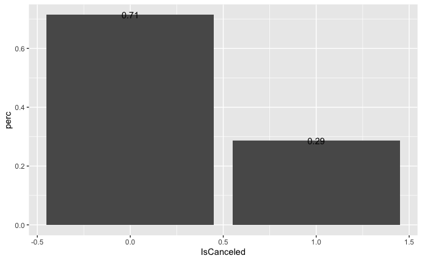

```r
target <- as.data.frame(raw_data_encoded_sample %>%group_by(IsCanceled)%>%summarise(counts = n()))%>%mutate(perc = counts/nrow(raw_data_encoded_sample))

ggplot(target, aes(x = IsCanceled, y = perc)) + geom_bar(stat = "identity")+
  geom_text(aes(label = round(perc,2)))
```

### PREDICTIVE VARIABLES

```r
#Predictive Variables: all of them except:
  # - IsCanceled (Target Variable) and ArrivalDateYear.
# We erase ArrivalDateYear because we won't our models to be time replicable.
predictiveVariables_sample = raw_data_encoded_sample[,c(-1,-3)]
```

## PREDICTION DATASET

```r
raw_data_prediction <- raw_data_encoded[-3]

# raw_data_prediction_sample <- raw_data_encoded_sample[-3]
# raw_data_prediction_sample = raw_data_prediction_sample[!sapply(raw_data_prediction_sample, function(x) sum(x)== 0)]
```

# CLUSTERING

Clustering: - Goodness of the cluster Analysis - Optimal Number of Clusters Clustering

## DATA PRE-PROCESSING

### SCALING

```r
#Scaled sample
predictiveVariables_sampleScaled = scale(predictiveVariables_sample)
predictiveVariables_sampleScaled = as.data.frame(predictiveVariables_sampleScaled)
```

### VARIABLES WITH ZERO VALUES IN ALL COLUMNS

```r
#Columns with all zeros from the sample
predictiveVariablesNonZero = predictiveVariables_sample[!sapply(predictiveVariables_sample, function(x) sum(x)== 0)]
predictiveVariablesNonZeroScaled = scale(predictiveVariablesNonZero)
```

```r
library(cluster)
gower_dist = daisy(as.matrix(predictiveVariables_sample) , metric = "euclidean", stand = FALSE)
```

[output not shown]

## GOODNESS OF THE CLUSTER ANALYSIS

```r
bondad_ac = get_clust_tendency(predictiveVariables_sample, 500)
bondad_ac$hopkins_stat
```

```
[1] 0.06892939
```

## OPTIMAL NUMBER OF CLUSTERS

### NUMBER FOR NON HIERARCHICAL CLUSTERING

#### GENERAL FOR ALL OF THEM

```r
clus.nb = NbClust(predictiveVariablesNonZeroScaled, distance = "euclidean",min.nc = 2, max.nc = 10,method = "complete", index ="gap")

clus.nb$Best.nc
```

```
Number_clusters     Value_Index
         2.0000          1.8945
```

#### PAM

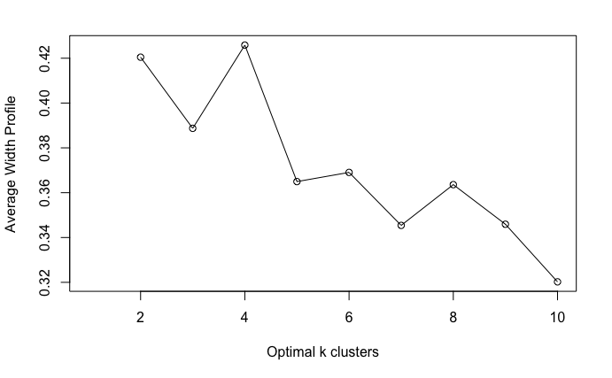

```r
# Calculate silhouette width for many k using PAM
sil_width <- c(NA)
for(i in 2:10){
  pam_fit <- pam(gower_dist,
                 diss = TRUE,
                 k = i)
  sil_width[i] <- pam_fit$silinfo$avg.width
}
# Plot sihouette width (higher is better)
plot(1:10, sil_width,
     xlab = "Optimal k clusters",
     ylab = "Average Width Profile")
lines(1:10, sil_width)
```

#### CLARA

```r
# Only numeric Variables for clustering
numericVariables <- predictiveVariablesNonZero[c(17,7,2,3,9,13,8,16,1,12,11,18,5,6,19)]
```

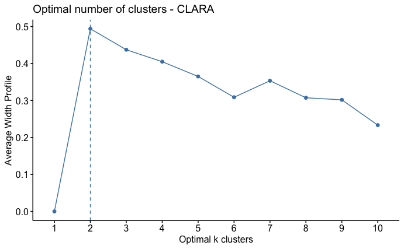

```r
fviz_nbclust(numericVariables, cluster::clara, method = "silhouette") + ggtitle("Optimal number of clusters - CLARA") + labs(x = "Optimal k clusters", y = "Average Width Profile")
```

```r
# 2 groups
```

The optimal number of clusters will be given by the value of k that maximizes the average profile. In this case: 2

#### FUZZY ANALYSIS CLUSTERING

```r
# Calculate silhouette width for many k using
sil_width <- c(NA)
for(i in 2:10){
 fanny_fit <- fanny(gower_dist,
                 diss = TRUE,
                 k = i)
  sil_width[i] <- fanny_fit$silinfo$avg.width
}
```

[output not shown]

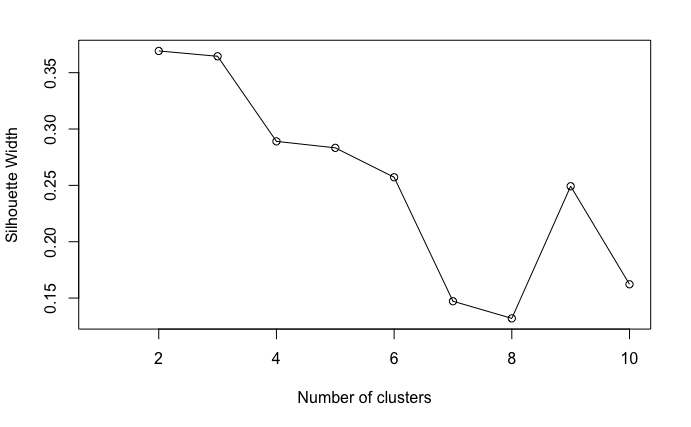

```r
# Plot sihouette width (higher is better)
plot(1:10, sil_width,
     xlab = "Number of clusters",
     ylab = "Silhouette Width")
lines(1:10, sil_width)
```

### NUMBER FOR HIERARCHICAL CLUSTERING

#### HCUT

```r
aggl.clust.c <- hclust(gower_dist, method = "complete")


library(fpc)
cstats.table <- function(dist, tree, k) {
  clust.assess <- c("cluster.number","n","within.cluster.ss","average.within","average.between","wb.ratio","dunn2","avg.silwidth")
  clust.size <- c("cluster.size")
  stats.names <- c()
  row.clust <- c()
  output.stats <- matrix(ncol = k, nrow = length(clust.assess))
  cluster.sizes <- matrix(ncol = k, nrow = k)
  for (i in c(1:k)) {
    row.clust[i] <- paste("Cluster-", i, " size")
  }
  for (i in c(2:k)) {
    stats.names[i] <- paste("Test", i - 1)

    for (j in seq_along(clust.assess)) {
      output.stats[j, i] <- unlist(cluster.stats(d = dist, clustering = cutree(tree, k = i))[clust.assess])[j]

    }

    for (d in 1:k) {
      cluster.sizes[d, i] <- unlist(cluster.stats(d = dist, clustering = cutree(tree, k = i))[clust.size])[d]
      dim(cluster.sizes[d, i]) <- c(length(cluster.sizes[i]), 1)
      cluster.sizes[d, i]

    }
  }
  output.stats.df <- data.frame(output.stats)
  cluster.sizes <- data.frame(cluster.sizes)
  cluster.sizes[is.na(cluster.sizes)] <- 0
  rows.all <- c(clust.assess, row.clust)

  # rownames(output.stats.df) <- clust.assess
  output <- rbind(output.stats.df, cluster.sizes)[ ,-1]
  colnames(output) <- stats.names[2:k]
  rownames(output) <- rows.all
  is.num <- sapply(output, is.numeric)
  output[is.num] <- lapply(output[is.num], round, 2)
  output
}
```

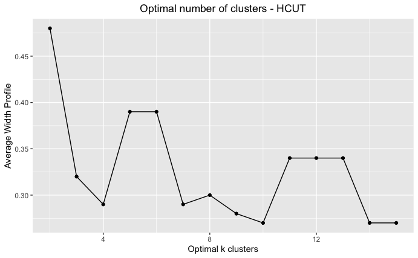

```r
ggplot(data = data.frame(t(cstats.table(gower_dist, aggl.clust.c, 15))),
       aes(x = cluster.number, y = avg.silwidth)) +
  geom_point() +
  geom_line() +
  ggtitle("Optimal number of clusters - HCUT") +
  labs(x = "Optimal k clusters", y = "Average Width Profile") +
  theme(plot.title = element_text(hjust = 0.5))
```

## HIERARCHICAL CLUSTERING

### DENDROGRAM

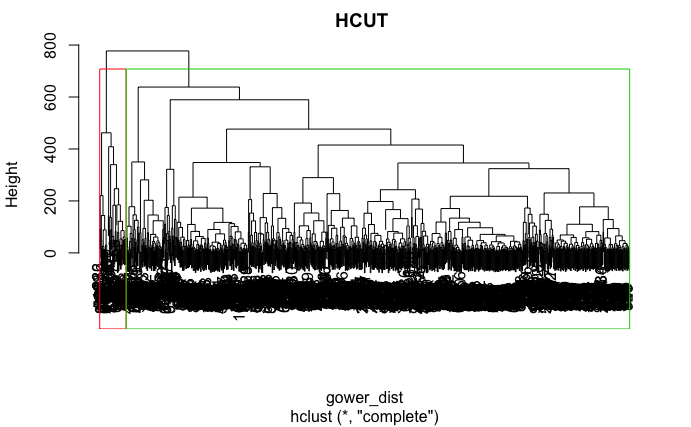

```r
plot(aggl.clust.c, main = "HCUT ")
rect.hclust(aggl.clust.c, k = 2, border = 2:3)
```

### CLUSTER PLOT

```
argument title is deprecated; please use main instead.
```

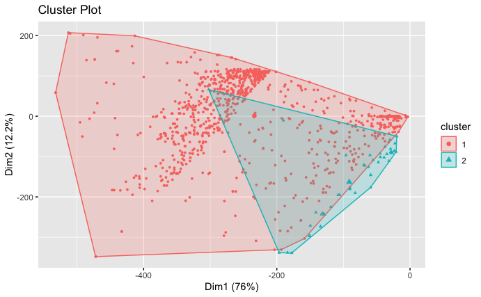

```r
set.seed(123)
grp <- cutree(aggl.clust.c, k = 2)
fviz_cluster(list(data = predictiveVariables_sample, cluster = grp), stand = FALSE, geom = "point", pointsize = 1, title = "Cluster Plot")
```

### CONTINGENCY TABLE

```r
clust.num <- cutree(aggl.clust.c, k = 2)
tabl = prop.table(table(clust.num,isCanceled_sample))*100
tabl
```

```
         isCanceled_sample
clust.num    0    1
        1 67.0 28.0
        2  4.4  0.6
```

```r
tabl[1,2]/(tabl[1]+ tabl[1,2])*100 # % of Cancelations of Group 1
```

```
[1] 29.47368
```

```r
tabl[2,2]/(tabl[2]+tabl[2,2])*100 # % of Cancelations of Group 2
```

```
[1] 12
```

### SILHOUETTE PLOT

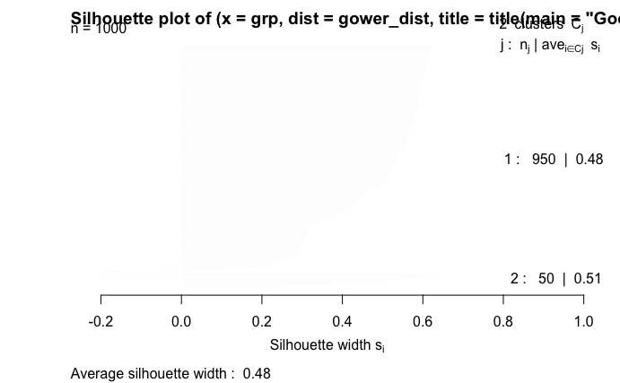

```r
grp <- cutree(aggl.clust.c, k = 2)
# aggl.clust.c <- hclust(gower_dist, method = "complete")
sil_cl <- silhouette(grp,gower_dist, title=title(main = 'Good'))
# rownames(sil_cl) <- rownames(grp)
plot(sil_cl)
```

## NON- HIERARCHICAL CLUSTERING

### PAM

#### CLUSTER PLOT

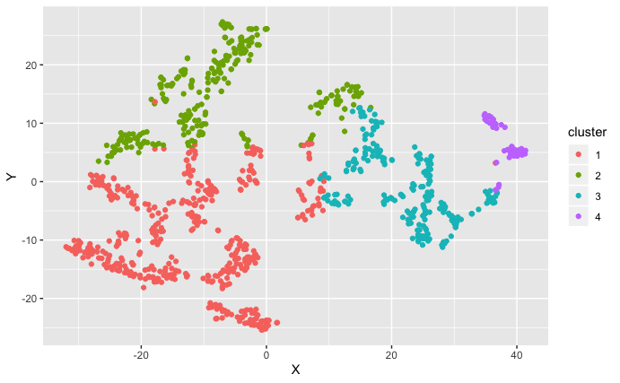

```r
library(Rtsne)
pam_fit <- pam(gower_dist, diss = TRUE, k = 4)

tsne_obj <- Rtsne(gower_dist, is_distance = TRUE)
tsne_data <- tsne_obj$Y %>%
  data.frame() %>%
  setNames(c("X", "Y")) %>%
  mutate(cluster = factor(pam_fit$clustering))
ggplot(aes(x = X, y = Y), data = tsne_data) +
  geom_point(aes(color = cluster))
```

#### CONTINGENCY TABLE

```r
pam_fit$clustering<- as.factor(pam_fit$clustering)
tabl = prop.table(table(pam_fit$clustering,isCanceled_sample))*100
tabl
```

```
   isCanceled_sample
       0    1
  1 33.2 11.6
  2 15.2 11.4
  3 18.5  5.0
  4  4.5  0.6
```

```r
tabl[1,2]/(tabl[1]+ tabl[1,2])*100 # % of Cancelations of Group 1
```

```
[1] 25.89286
```

```r
tabl[2,2]/(tabl[2]+tabl[2,2])*100 # % of Cancelations of Group 2
```

```
[1] 42.85714
```

```r
tabl[3,2]/(tabl[3]+tabl[3,2])*100 # % of Cancelations of Group 3
```

```
[1] 21.2766
```

```r
tabl[4,2]/(tabl[4]+tabl[4,2])*100 # % of Cancelations of Group 4
```

```
[1] 11.76471
```

```r
# tabl[5,2]/(tabl[5]+tabl[5,2])*100 # % of Cancelations of Group 5
# tabl[6,2]/(tabl[6]+tabl[6,2])*100 # % of Cancelations of Group 6
# tabl[7,2]/(tabl[7]+tabl[7,2])*100 # % of Cancelations of Group 7
# tabl[8,2]/(tabl[8]+tabl[8,2])*100 # % of Cancelations of Group 8
# tabl[9,2]/(tabl[9]+tabl[9,2])*100 # % of Cancelations of Group 9
# tabl[10,2]/(tabl[10]+tabl[10,2])*100 # % of Cancelations of Group 10
```

#### SILHOUETTE PLOT

|  | cluster | size | ave.sil.width |
| --- | --- | --- | --- |
| 1 | 1 | 448 | 0.47 |
| 2 | 2 | 266 | 0.29 |
| 3 | 3 | 235 | 0.50 |
| 4 | 4 | 51 | 0.41 |

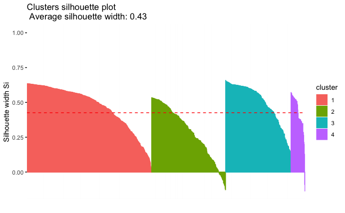

```r
fviz_silhouette(pam_fit)
```

### CLARA

#### CLUSTER PLOT

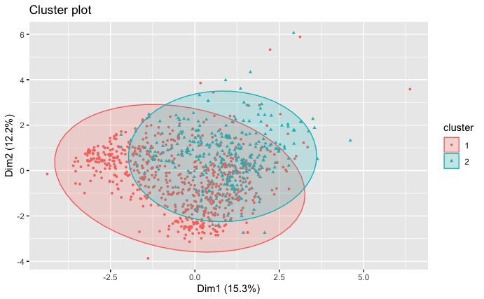

```r
library(cluster)
claraC2 = clara(numericVariables, 2,
                    samples = 1000, correct.d = FALSE)
fviz_cluster(claraC2, geom = "point", pointsize = 1, ellipse.type = "norm")
```

#### CONTINGENCY TABLE

```r
claraC2$clustering <- as.factor(claraC2$clustering)
tabl = prop.table(table(claraC2$clustering,isCanceled_sample))*100
tabl
```

```
   isCanceled_sample
       0    1
  1 49.5 15.2
  2 21.9 13.4
```

```r
tabl[1,2]/(tabl[1] + tabl[1,2])*100 # % of Cancelations of Group 1
```

```
[1] 23.49304
```

```r
tabl[2,2]/(tabl[2] + tabl[2,2])*100 # % of Cancelations of Group 2
```

```
[1] 37.96034
```

#### SILHOUETTE PLOT

|  | cluster | size | ave.sil.width |
| --- | --- | --- | --- |
| 1 | 1 | 25 | 0.59 |
| 2 | 2 | 19 | 0.48 |

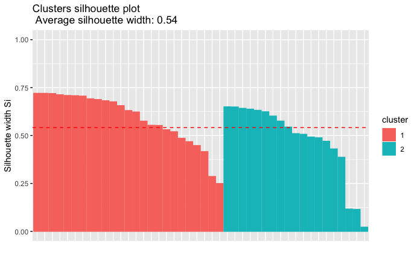

```r
fviz_silhouette(claraC2)
```

### FUZZY ANALYSIS CLUSTERING

#### CLUSTER PLOT

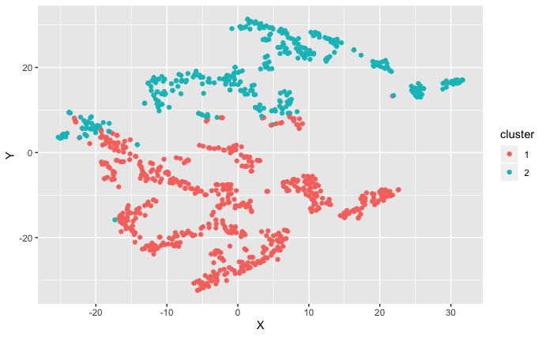

```r
library(Rtsne)
fanny_fit <- fanny(gower_dist, diss = TRUE, k = 2)

tsne_obj <- Rtsne(gower_dist, is_distance = TRUE)
tsne_data <- tsne_obj$Y %>%
  data.frame() %>%
  setNames(c("X", "Y")) %>%
  mutate(cluster = factor(fanny_fit$clustering))
ggplot(aes(x = X, y = Y), data = tsne_data) +
  geom_point(aes(color = cluster))
```

```r
# Coeficiente de segmentación normalizado:
fanny_fit$coeff
```

```
 dunn_coeff  normalized
0.504429626 0.008859251
```

#### CONTINGENCY TABLE

```r
fanny_fit$clustering <- as.factor(fanny_fit$clustering)
tabl = prop.table(table(fanny_fit$clustering,isCanceled_sample))*100
tabl
```

```
   isCanceled_sample
       0    1
  1 42.1 18.2
  2 29.3 10.4
```

```r
tabl[1,2]/(tabl[1]+ tabl[1,2])*100 # % of Cancelations of Group 1
```

```
[1] 30.18242
```

```r
tabl[2,2]/(tabl[2]+tabl[2,2])*100 # % of Cancelations of Group 2
```

```
[1] 26.19647
```

#### SILHOUETTE PLOT

|  | cluster | size | ave.sil.width |
| --- | --- | --- | --- |
| 1 | 1 | 603 | 0.50 |
| 2 | 2 | 397 | 0.17 |

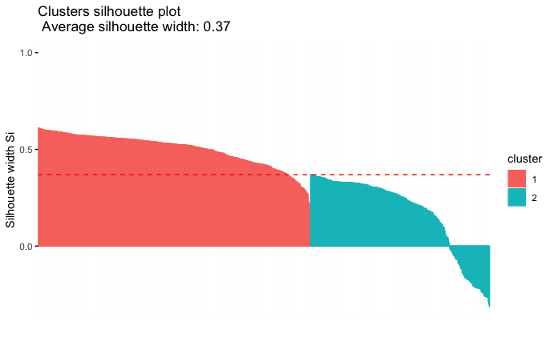

```r
fviz_silhouette(fanny_fit)
```

# DIMENSIONALITY REDUCTION

## CORRESPONDENCE ANALYSIS

### RESERVED ROOM VS DISTRIBUTION CHANNEL

```r
roomChannel = as.data.frame.matrix(table(raw_data$DistributionChannel, raw_data$ReservedRoomType))
roomChannel
```

|  | A | B | C | D | E | F | G | H | L | P |
| --- | --- | --- | --- | --- | --- | --- | --- | --- | --- | --- |
| Corporate | 2858 | 0 | 22 | 186 | 177 | 9 | 15 | 2 | 0 | 0 |
| Direct | 3932 | 3 | 327 | 1326 | 1063 | 700 | 359 | 149 | 6 | 0 |
| TA/TO | 16608 | 0 | 569 | 5921 | 3742 | 397 | 1236 | 450 | 0 | 2 |
| Undefined | 1 | 0 | 0 | 0 | 0 | 0 | 0 | 0 | 0 | 0 |

```r
as.table(as.matrix(roomChannel))
```

```
              A     B     C     D     E     F     G     H     L     P
Corporate  2858     0    22   186   177     9    15     2     0     0
Direct     3932     3   327  1326  1063   700   359   149     6     0
TA/TO     16608     0   569  5921  3742   397  1236   450     0     2
Undefined     1     0     0     0     0     0     0     0     0     0
```

```r
roomChannelScaled = scale(roomChannel)
roomChannelScaled
```

```
                   A    B          C          D          E          F           G
Corporate -0.4064036 -0.5 -0.7653874 -0.6034377 -0.6183163 -0.7924045 -0.66824351
Direct    -0.2605099  1.5  0.3596399 -0.1920644 -0.1056085  1.2545170 -0.07501572
TA/TO      1.4614159 -0.5  1.2522845  1.4660587  1.4446670  0.3569523  1.43737023
Undefined -0.7945025 -0.5 -0.8465369 -0.6705565 -0.7207421 -0.8190648 -0.69411100
                     H    L    P
Corporate -0.700403037 -0.5 -0.5
Direct    -0.005905591  1.5 -0.5
TA/TO      1.416160610 -0.5  1.5
Undefined -0.709851982 -0.5 -0.5
attr(,"scaled:center")
      A       B       C       D       E       F       G       H       L       P
5849.75    0.75  229.50 1858.25 1245.50  276.50  402.50  150.25    1.50    0.50
attr(,"scaled:scale")
        A         B         C         D         E         F         G         H         L
7361.5250    1.5000  271.1045 2771.2056 1728.0800  337.5801  579.8784  211.6638    3.0000
        P
   1.0000
```

#### Independence Test

```r
test.ind = chisq.test(roomChannel)
```

```
Chi-squared approximation may be incorrect
```

```r
test.ind
```

```
    Pearson's Chi-squared test

data:  roomChannel
X-squared = 2800, df = 27, p-value < 2.2e-16
```

```r
# The result of the test confirms the possibility of rejecting the hypotheses of independence between categories of rows and columns, or, what is the same, we can affirm that there is a relationship between them. The rest of the tests presented below allow us to help visualize and interpret the test result.
```

#### Analysis

```r
roomChannelt = as.table(as.matrix(roomChannel))
roomChannelt
```

[output not shown]

```r
library("FactoMineR")
# tab1 <- as.data.frame.matrix(table(as.factor(df$X1),as.factor(df$X2)))
# res.ca <- CA(tab1, graph = FALSE)
```

```r
library(FactoMineR)
roomChannel.ca=CA(roomChannel, graph = FALSE)
```

```r
summary(roomChannel.ca)
```

```
Call:
CA(X = roomChannel, graph = FALSE)

The chi square of independence between the two variables is equal to 2800.024 (p-value =  0 ).

Eigenvalues
                       Dim.1   Dim.2   Dim.3
Variance               0.048   0.022   0.000
% of var.             68.383  31.617   0.000
Cumulative % of var.  68.383 100.000 100.000

Rows
            Iner*1000    Dim.1    ctr   cos2    Dim.2    ctr   cos2    Dim.3    ctr   cos2
Corporate |    28.759 | -0.440 32.986  0.548 | -0.399 58.794  0.452 |  0.000  0.060  0.000
Direct    |    33.753 |  0.389 62.235  0.881 | -0.143 18.132  0.119 |  0.000  0.000  0.000
TA/TO     |     7.366 | -0.056  4.762  0.309 |  0.084 23.034  0.691 |  0.000  0.001  0.000
Undefined |     0.018 | -0.589  0.018  0.487 | -0.596  0.040  0.499 |  0.098 99.939  0.014

Corporate |
Direct    |
TA/TO     |
Undefined |

Columns
            Iner*1000    Dim.1    ctr   cos2    Dim.2    ctr   cos2    Dim.3    ctr   cos2
A         |    14.274 | -0.129 20.264  0.679 | -0.089 20.762  0.321 |  0.000  0.564  0.000
B         |     0.307 |  1.780  0.497  0.774 | -0.961  0.313  0.226 |  0.000  0.003  0.000
C         |     4.249 |  0.427  8.735  0.983 | -0.057  0.332  0.017 |  0.000  1.402  0.000
D         |     9.015 |  0.063  1.528  0.081 |  0.211 37.490  0.919 |  0.000  0.524  0.000
E         |     3.568 |  0.116  3.475  0.466 |  0.124  8.627  0.534 | -0.001 47.484  0.000
F         |    33.671 |  1.018 59.897  0.850 | -0.427 22.815  0.150 |  0.000  0.249  0.000
G         |     2.836 |  0.181  2.758  0.465 |  0.194  6.866  0.535 |  0.001 29.712  0.000
H         |     1.345 |  0.242  1.845  0.656 |  0.176  2.096  0.344 |  0.002 19.886  0.000
L         |     0.613 |  1.780  0.993  0.774 | -0.961  0.626  0.226 |  0.000  0.005  0.000
P         |     0.019 | -0.257  0.007  0.171 |  0.565  0.072  0.829 |  0.003  0.170  0.000

A         |
B         |
C         |
D         |
E         |
F         |
G         |
H         |
L         |
P         |
```

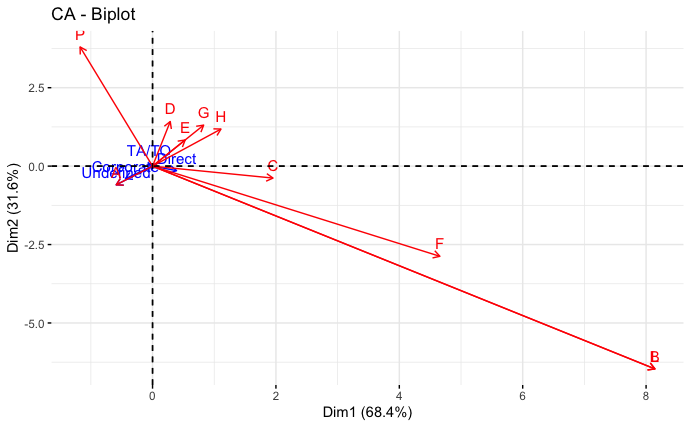

```r
fviz_ca_biplot(roomChannel.ca, map ="rowprincipal", arrow = c(TRUE, TRUE))
```

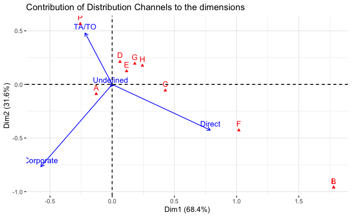

```r
fviz_ca_biplot(roomChannel.ca, map ="colgreen",
               arrow = c(TRUE, FALSE))+
        ggtitle("Contribution of Distribution Channels to the dimensions")
```

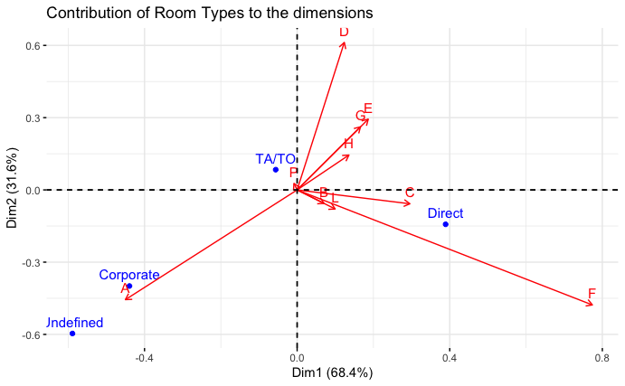

```r
fviz_ca_biplot(roomChannel.ca, map ="rowgreen",
               arrow = c(FALSE, TRUE))+
        ggtitle("Contribution of Room Types to the dimensions")
```

### COUNTRY VS RESERVED ROOM

```r
countryRoom = as.data.frame.matrix(table(raw_data$Country, raw_data$ReservedRoomType))
countryRoom
```

|  | A | B | C | D | E | F | G | H | L | P |
| --- | --- | --- | --- | --- | --- | --- | --- | --- | --- | --- |
| AGO | 10 | 0 | 1 | 2 | 7 | 0 | 3 | 1 | 0 | 0 |
| ALB | 2 | 0 | 0 | 1 | 0 | 0 | 0 | 0 | 0 | 0 |
| AND | 1 | 0 | 1 | 1 | 0 | 0 | 1 | 1 | 0 | 0 |
| ARE | 4 | 0 | 1 | 0 | 2 | 0 | 3 | 1 | 0 | 0 |
| ARG | 23 | 0 | 4 | 6 | 12 | 2 | 8 | 2 | 0 | 0 |
| ARM | 0 | 0 | 0 | 2 | 0 | 0 | 0 | 0 | 0 | 0 |
| AUS | 36 | 0 | 0 | 14 | 18 | 5 | 8 | 6 | 0 | 0 |
| AUT | 96 | 0 | 2 | 46 | 43 | 3 | 18 | 2 | 0 | 0 |
| AZE | 3 | 0 | 0 | 0 | 0 | 0 | 0 | 0 | 0 | 0 |
| BDI | 1 | 0 | 0 | 0 | 0 | 0 | 0 | 0 | 0 | 0 |

[output cut: 116 more lines]

#### Independence Test

```r
test.ind = chisq.test(countryRoom)
```

```
Chi-squared approximation may be incorrect
```

```r
test.ind
```

```
    Pearson's Chi-squared test

data:  countryRoom
X-squared = 3320.9, df = 1125, p-value < 2.2e-16
```

```r
# The result of the test confirms the possibility of rejecting the hypotheses of independence between categories of rows and columns, or, what is the same, we can affirm that there is a relationship between them. The rest of the tests presented below allow us to help visualize and interpret the test result.
```

#### Analysis

```r
library(FactoMineR)
countryRoom.ca=CA(countryRoom, graph = FALSE)
```

```r
summary(countryRoom.ca)
```

```
Call:
CA(X = countryRoom, graph = FALSE)

The chi square of independence between the two variables is equal to 3320.869 (p-value =  3.456894e-215 ).

Eigenvalues
                       Dim.1   Dim.2   Dim.3   Dim.4   Dim.5   Dim.6   Dim.7   Dim.8
Variance               0.035   0.018   0.010   0.008   0.006   0.003   0.003   0.000
% of var.             41.857  21.528  11.696  10.219   7.127   4.209   3.226   0.094
Cumulative % of var.  41.857  63.385  75.081  85.300  92.427  96.637  99.863  99.957
                       Dim.9
Variance               0.000
% of var.              0.043
Cumulative % of var. 100.000

Rows (the 10 first)
       Iner*1000    Dim.1    ctr   cos2    Dim.2    ctr   cos2    Dim.3    ctr   cos2
AGO  |     0.359 |  0.451  0.351  0.339 |  0.393  0.518  0.258 | -0.181  0.203  0.055 |
ALB  |     0.027 | -0.250  0.013  0.173 | -0.385  0.062  0.413 |  0.114  0.010  0.036 |
AND  |     0.586 |  0.765  0.210  0.125 |  1.474  1.519  0.463 |  0.054  0.004  0.001 |
ARE  |     0.619 |  0.669  0.354  0.198 |  1.224  2.306  0.665 | -0.017  0.001  0.000 |
ARG  |     0.749 |  0.451  0.834  0.386 |  0.514  2.108  0.502 |  0.090  0.119  0.015 |
ARM  |     0.219 |  0.860  0.106  0.169 | -1.373  0.527  0.430 |  0.512  0.135  0.060 |
AUS  |     0.921 |  0.445  1.239  0.467 |  0.269  0.878  0.170 | -0.376  3.174  0.334 |
AUT  |     0.806 |  0.304  1.396  0.601 | -0.039  0.045  0.010 | -0.029  0.046  0.005 |
AZE  |     0.053 | -0.804  0.140  0.909 |  0.108  0.005  0.017 | -0.085  0.006  0.010 |
BDI  |     0.018 | -0.804  0.047  0.909 |  0.108  0.002  0.017 | -0.085  0.002  0.010 |

Columns
       Iner*1000    Dim.1    ctr   cos2    Dim.2    ctr   cos2    Dim.3    ctr   cos2
A    |    13.410 | -0.150 37.794  0.978 |  0.014  0.687  0.009 | -0.008  0.419  0.003 |
B    |     0.085 | -0.556  0.067  0.272 |  0.395  0.065  0.137 |  0.221  0.038  0.043 |
C    |     8.898 |  0.048  0.152  0.006 |  0.347 15.500  0.311 |  0.392 36.390  0.397 |
D    |    13.372 |  0.160 13.728  0.356 | -0.183 34.987  0.467 |  0.050  4.865  0.035 |
E    |    11.829 |  0.245 21.458  0.629 | -0.052  1.871  0.028 | -0.092 10.860  0.089 |
F    |     5.157 |  0.251  5.016  0.337 |  0.115  2.033  0.070 |  0.052  0.762  0.014 |
G    |    14.496 |  0.389 17.536  0.420 |  0.346 26.905  0.331 |  0.107  4.750  0.032 |
H    |    11.199 |  0.265  3.036  0.094 |  0.460 17.818  0.284 | -0.515 41.012  0.355 |
L    |     0.191 | -0.751  0.243  0.443 |  0.258  0.056  0.052 |  0.075  0.009  0.004 |
P    |     4.260 | -2.597  0.970  0.079 |  0.527  0.078  0.003 | -1.320  0.897  0.020 |
```

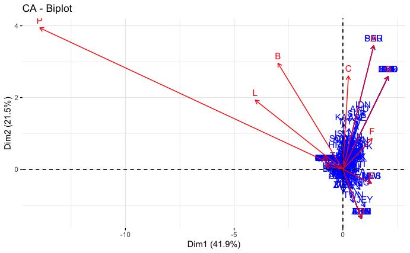

```r
fviz_ca_biplot(countryRoom.ca, map ="rowprincipal", arrow = c(TRUE, TRUE))
```

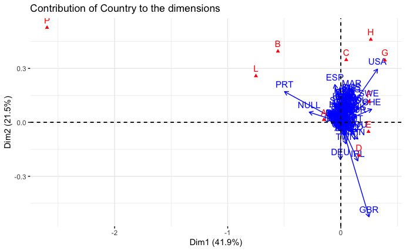

```r
fviz_ca_biplot(countryRoom.ca, map ="colgreen",
               arrow = c(TRUE, FALSE))+
        ggtitle("Contribution of Country to the dimensions")
```

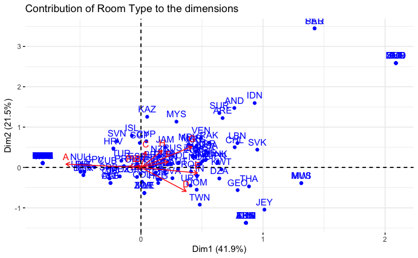

```r
fviz_ca_biplot(countryRoom.ca, map ="rowgreen",
               arrow = c(FALSE, TRUE))+
        ggtitle("Contribution of Room Type to the dimensions")
```